## Demo: Wide and Narrow

```r
require(rworldmap)
data(countrySynonyms)
```

`View()` the `countrySynonyms` table. Is this in wide or narrow format? What would the other format look like?

To convert it to narrow format … Hint: In the end, you may not need the “key” variable.

```r
require(tidyr)
Translate <-
  countrySynonyms %>%
  select(-ID) %>%
  mutate( ISO3=toupper(ISO3)) %>%
  gather( value=country, key=bogus, name1:name8) %>%
  select( -bogus ) %>%
  mutate( country=ifelse(country %in% c("","<NA>"), NA, country)) %>%
  na.omit
```

Ideas about which is to be preferred?

## All together:

Population by ISO2 and ISO3

Country Codes at …

http://www.fao.org/countryprofiles/iso3list/en/

Country Synonyms:

```r
Synonyms <- fetchData("DCF/CountrySynonyms.csv")
```

```
## Retrieving from http://www.mosaic-web.org/go/datasets/DCF/CountrySynonyms.csv
```

ISO2 and ISO3 codes

```r
Codes <- fetchData("DCF/CountryCodes.csv")
```

```
## Retrieving from http://www.mosaic-web.org/go/datasets/DCF/CountryCodes.csv
```

1. Pull out the country and population data from `CountryData`
2. Translate `country` in `CountryData` to `ISO3` using `Synonyms`
3. Then translate `ISO3` to `ISO2` using `Codes`
4. Merge with `WorldCities` by `country`/`ISO2`

## World Cities

Check the table for plausibility.  
* What’s the total number of people represented?

```r
WorldCities %>%
  summarise( total=sum(population))
```

```
##        total
## 1 2592396767
```

- How many cities larger than 100,000? Than 1,000,000?
- Make a scatterplot of the latitude and longitude of the cities larger than 100K

```r
p <-
  WorldCities %>%
  filter( population > 1e5 ) %>%
  ggplot( aes(x=longitude, y=latitude )) +
    geom_point(alpha=.1, aes(size=population)) +
    scale_size_area()
```

- What’s the biggest city in each country?

```r
BiggestByCountry <-
  WorldCities %>%
  group_by( country ) %>%
  filter( rank(desc(population)) == 1 )
```

Add that to the plot as another layer. Make it red.

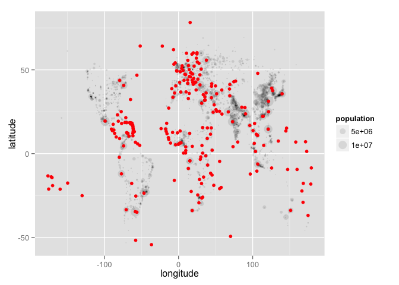

```r
p + geom_point( data=BiggestByCountry, color='red')
```

- Countries where the biggest city is more than 5M people

```r
BiggestByCountry %>%
  filter( population > 5000000)
```

```
## Source: local data frame [24 x 10]
## Groups: country
##
##       code          name  latitude longitude country
## 1  3435910  Buenos Aires -34.61315 -58.37723      AR
## 2  1185241         Dhaka  23.71040  90.40744      BD
## 3  3448439     Sao Paulo -23.54750 -46.63611      BR
## 4  2314302      Kinshasa  -4.32142  15.30807      CD
## 5  1796236      Shanghai  31.22222 121.45806      CN
## 6  3688689        Bogota   4.60971 -74.08175      CO
## 7   360630         Cairo  30.06263  31.24967      EG
## 8  1819729     Hong Kong  22.28552 114.15769      HK
## 9  1642911       Jakarta  -6.21462 106.84513      ID
## 10 1275339        Mumbai  19.07283  72.88261      IN
## 11   98182       Baghdad  33.34058  44.40088      IQ
## 12  112931        Tehran  35.69439  51.42151      IR
## 13 1850147         Tokyo  35.68950 139.69171      JP
## 14 1835848         Seoul  37.56826 126.97783      KR
## 15 3530597   Mexico City  19.42847 -99.12766      MX
## 16 2332459         Lagos   6.45306   3.39583      NG
## 17 3936456          Lima -12.04318 -77.02824      PE
## 18 1701668        Manila  14.60420 120.98220      PH
## 19 1174872       Karachi  24.90560  67.08220      PK
## 20  524901        Moscow  55.75222  37.61556      RU
## 21 1609350       Bangkok  13.75398 100.50144      TH
## 22  745044      Istanbul  41.01384  28.94966      TR
## 23 1668341        Taipei  25.04776 121.53185      TW
## 24 5128581 New York City  40.71427 -74.00597      US
## Variables not shown: countryRegion (chr), population (dbl),
##   regionCode (int), region (chr), date (chr)
```

Connecting with population …

## In Groups

Working with your group, figure out a strategy for adding in, for each country, the total population of that country.

## Give them `CountryByISO2`

- Country name synonyms
- Cities that are the largest, by fraction of the population, in each country.
  - Need the country population data: from `CountryData`

  ```r
  Population <-
    CountryData %>%
    select( country, pop )
  ```

Now join these to the `WorldCities` data …

`WorldCities` has ISO-2 country codes.

`CountryData` had common names (in English). We need to translate from one to the other.

A table is available via

```r
Codes <- fetchData("DCF/CountryCodes.csv")
```

```
## Retrieving from http://www.mosaic-web.org/go/datasets/DCF/CountryCodes.csv
```

Pull out the country and ISO-2 variables

```r
Codes <-
  Codes %>%
  select(country, ISO2)
```

Join with `Population`

```r
Population <-
  Population %>%
  inner_join( Codes )
```

Add `ISO2` column to `WorldCities` in place of `country`

```r
WorldCities <-
  WorldCities %>%
  mutate( ISO2=country) %>%
  select( -country )
```

Merge `Population` with `WorldCities` on `ISO2`

```r
WorldCities <-
  WorldCities %>%
  inner_join( Population )
```

World cities:

The basic questions …

- Northernmost, Southermost Closest to the equator
- Fraction of country population that lives in cities.
- Countries where the biggest city is twice as large as the next biggest.
- Compare the pop of the biggest city to the other cities. Find the rank of the city that is less than half the population of the biggest cities.

## Medicare

Generate city-wise population, age, race statistics.

For a given DRG, or body-system, look at per-capita number of procedures as function of age.

How many of the US cities are in the World Cities data table?

Find the cities that don’t have a match.

For each city in the US, find the area of that city, the population density etc.

Plot out the old-age cities.

Plot out the cities

For each DRG, find the three top and bottom states in terms of number of procedures per capita.

Graphing networks: just a demo

Long and narrow: just a demo

# Global migration – Everyone together

http://data.worldbank.org/data-catalog/global-bilateral-migration-database

Countries that send people to the US. Make a map.

Trends over time of countries that send people to the US. (Convert to narrow, use `geom_lines()` with `group` property.)

Set color by GDP of the sending country.

Bilateral migration — put the inbound and outbound migration as different variables. A network based on …

- Balance between countries
- What’s total migration as a fraction of the population?
- Which countries have strong gender imbalance of migration?

### Rank

Within each state, pull out the 100 zip codes with the highest minority populations. Plot these out on a choropleth map of overall minority population. (Or, maybe, foreign born.)

# Class Notes: Week 4

Drill on wide/narrow:  
* pivot, fold, gather, spread, unite, … * NCI60 — just the probe data. Change to narrow format and find the probes with the highest standard deviation of expression across all cell lines.

Baby names: put the boy count side by side with the girl count. Then find the names that are given to both boys and girls.

### Rank

Within each state, pull out the 100 zip codes with the highest minority populations. Plot these out on a choropleth map of overall minority population. (Or, maybe, foreign born.)

You’re doing the background research for a birdwatching manual.

- In the bird data, for each month, pull out the 4 highest species.
- Pull out the species that are in the top 20 every month. These are the year-round birds.
- Modify the 4 highest in each-month to exclude the year-round birds. (This will be an anti-join.

For each country, pull out the two countries that have the strongest bilateral immigration. Make a network graph of these

### Long and Narrow

Turn the immigration data into narrow, so that you can calculate the pairs that are close to being bilateral.

Doing a transform on a grouped variable allows you, if you want, to use aggregate quantities for that group. For instance, the groups of males and females have different mean heights. Here’s how you would calculate the difference of an individual from his or her group’s mean.

```r
NHANES <- group_by( NHANES, sex )
NHANES <- mutate( NHANES, dheight=height-mean(height) )
summarise( NHANES, sd(dheight) )
```

## Still to do

Do a tabulation of the rank-choice data.

Find the variances of the NCI data, by probe.

Cross-tab of NHANES: perhaps cardiac death versus sex or BMI.

Using `ggplot()` directly. Layers …

## Constructing the Chart

Consider three different grammar components of the charts:

1. Frame
2. Glyphs, known as *geoms* in `ggplot2`.
3. Facets

There must always be a frame and at least one glyph layer in a (non-empty) chart.

Write down an appropriate `ggplot2` statement for generating each component. Say what aesthetics apply to each layer. (Any layer can inherit aesthetics from the frame, or can override them.) Take `TheData` to be a data frame containing relevant variables. If other dataframes are needed, call them `Data1`, `Data2`, etc.

1. Frame: `ggplot( data = TheData, ? )`
2. Layer 1:
3. Layer 2:
4. Layer 3:
5. Faceting:

Write down an appropriate command to construct the graph (or something like it). As a reminder, here are a few of the `ggplot2` functions:

`ggplot()`, `geom_point()`, `geom_barchart()`, `geom_blank()`, `geom_boxplot()`, `geom_density()`, `geom_errorbar()`, `geom_polygon()`, `geom_line()`, `geom_path()`, `geom_ribbon()`, `geom_rug()`, `geom_text()`, `scale_y_log10()`, `scale_x_log10()`, `xlab()`, `ylab()`, `ggtitle()`